# Incarceration Report

## Introduction

- United States is the most incarcerated country in the world due to the significant contribution of systemic racism.
- For example, the prison system reveals to target individuals of color through over-policing and the war on drugs, leading to the disproportionate incarceration of people of color.
- Through this report, I am examining the patterns of inequality using the incarceration data collected by the [Vera Institute](https://github.com/vera-institute/incarceration-trends). I am examining jail population rates by different races in different states, and specfically Texas.

### Summary

```r
summary_info
```

[output not shown]

- In 2018, Colorado had the highest black to white jail ratio.
- In 2004, Texas had the highest rate of black people in jail.
- In 2018,Georgia had the highest rate of Latin Americans in jail.
- In 2018, Louisiana had the lowest rate of white people in jail.
- In 2018, Georgia had the highest rate of Asian Americans in jail.

### Black Jail Population Rates Disproportionately Higher than White Rates

This scatter plot displays the white jail population rates on the y axis and the black jail population rate on the x axis. This plot reveals how states have disproportionate incarceration rates among black and white people. For example, in Campbell County, Wyoming, there is a white jail population rate of 138.22, which is significantly lower than their black jail population rate of 34883.72.

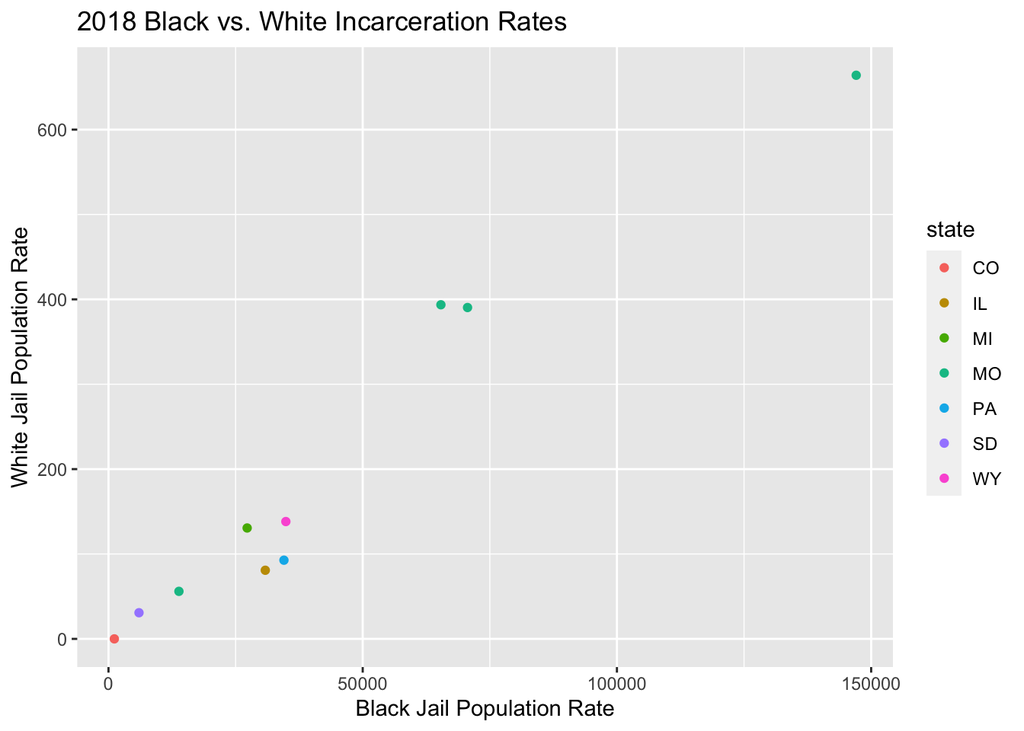

### 2018 Texas Map of Black/White Incarceration Ratios

This map displays the differences in black to white incarceration ratios by counties in Texas of 2018. There are quite of lighter blue counties, which have a higher black to white incarceration ratio. For example, Terrell County has a black to white incarceration ratio of 41.99987.

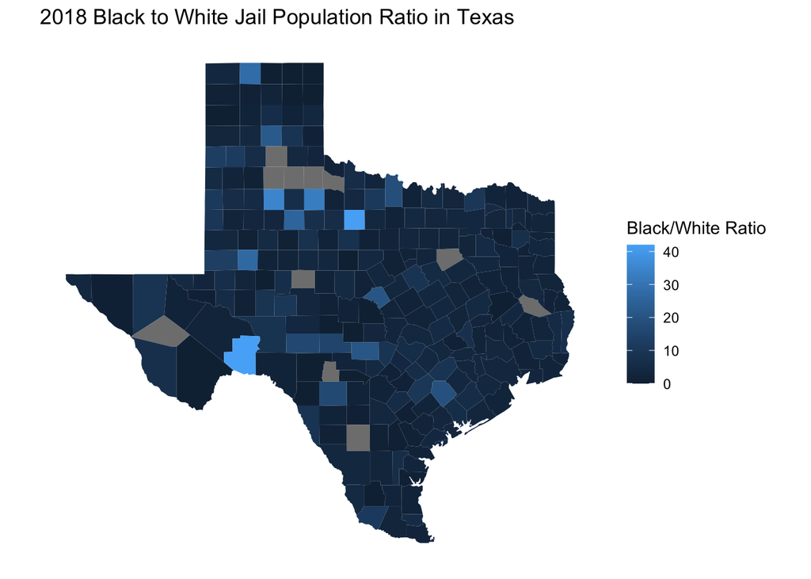

### Terrell County, Texas Incarceration Rates by Race Since 1990

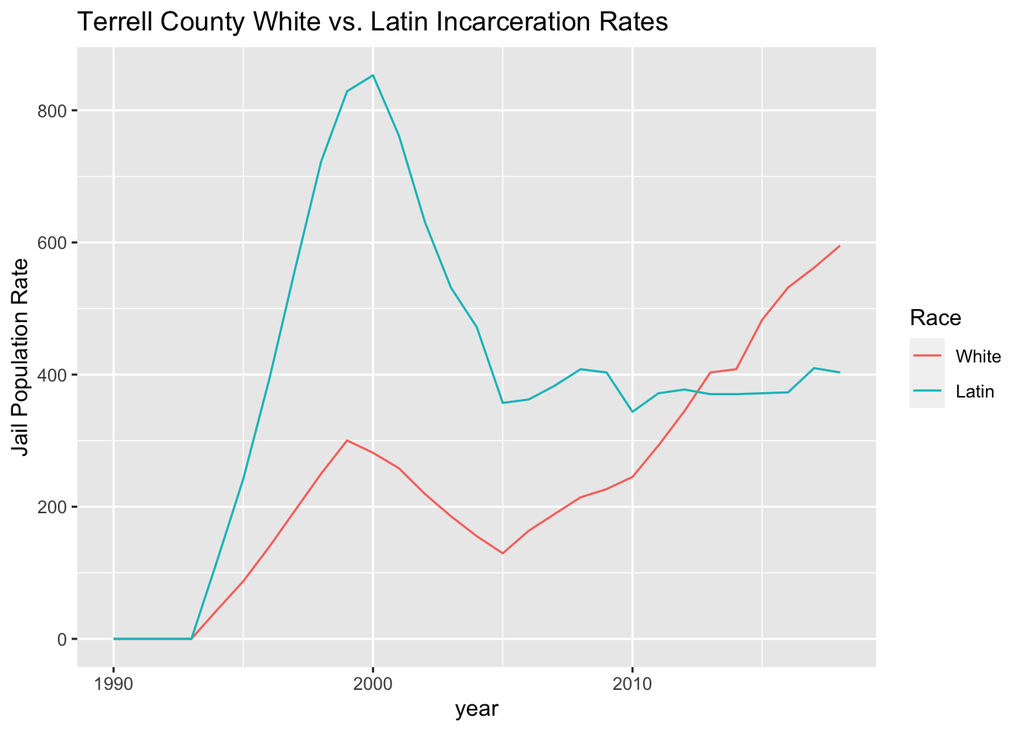

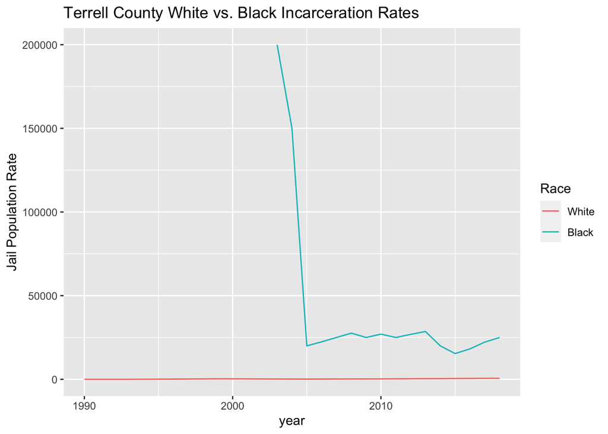